# Tarea 2: Equipo 5

*Jorge III Altamirano Astorga - 175904*

*Eduardo Selim Martinez Mayorga - 175921*

*Ariel Ernesto Vallarino Maritorena - 175875*

## Tarea 2: Hadoop, HDFS

Utilizamos la imagen de [docker.io/sequenceiq/hadoop-docker](https://store.docker.com/community/images/sequenceiq/ha) con el comando:

`docker run -it --rm -p 8088:8088 -v /tmp:/root/tarea_2 sequenceiq/hadoop-docker:2.7.0 /etc/bootstrap.sh -bash`

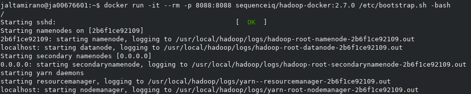

*La opción* `-v` *es para tener un volumen dentro del container donde descargamos los datos de Dropbox.*

*El Dockerfile está en el penúltimo tab.*

### Creación del directorio

Crear el directorio `/metodos_gran_escala/tarea_2/ecobici/year=2017/sem_1/` con `mkdir` verifica la opción `-p`

*Respecto a la sección* `$HADOOP_PREFIX/bin` *es para evitar tenernos que mover de directorio y teclear todo, pues el shell acepta autocompletar con la tecla “tabulador” las variables de ambiente :-)*

### Listado del directorio

Muestra que el directorio está vacío -no hay datos cargados- con ls

*Aquí mostramos la ejecución de todo el arbol de directorios, *resaltando* en color rojo lo que se pidió; esto con el comando* `hdfs dfs -ls /metodos_gran_escala/tarea_2/ecobici/year=2017/sem_1/`.

*Hemos puesto todo el árbol para mostrar de manera explícita el árbol de directorios.*

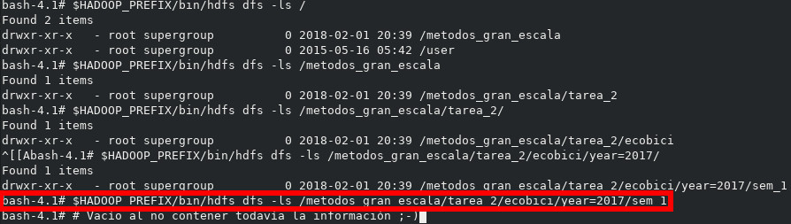

### Carga de datos

Carga los datos a este directorio que creaste ocupando copyFromLocal

*Aquí se muestra la ejecución del comando* `$HADOOP_PREFIX/bin/hdfs dfs -copyFromLocal /root/tarea_2/ecobici_2017_sem1.csv '/metodos_gran_escala/tarea_2/ecobici/year=2017/sem_1/'`

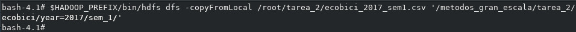

*Salida sin errores. Los datos los cargamos desde la carpeta `/root/tarea_2`,* que viene del volumen mapeado en la creación del container, con la opción:_ `-v /tmp:/root/tarea_2`. *Los datos fueron descargados con browser y no se pudo con curl o wget, dado que requiere la sesión, al menos por lo que intentamos.*

### Mostrar datos cargados

Muestra que los datos están cargados haciendo un ls

*Aquí se muestra la ejecución del comando sin y con la opción -h para mostrarlo en Gigas en vez de bytes. Esto puede ser cómodo para el operador, pero engañoso, pues pueden no coincidir los bytes. Pero para darnos una idea rápida es útil.* `$HADOOP_PREFIX/bin/hdfs dfs -ls -h '/metodos_gran_escala/tarea_2/ecobici/year=2017/sem_1/'`

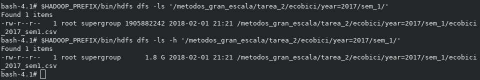

*Salida sin errores con el tamaño de 1.8 GB (1905882242 bytes) al igual que el archivo original.*

### Mostrar elementos del HDFS

Muestra que el NameNode, DataNode, ResourceManager y el NodeManager están activos en tu clúster de Hadoop con jps

*Se muestra la salida del comando* `jps` *con los NameNode (1), DataNode (2), ResourceManager(3) y el NodeManager (4). Hemos marcado con número rojo (GIMP) cada uno de los elementos sólo con fines informativos, no es parte de la salida del comando.*

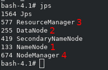

### Reporte de dfsadmin

Muestra la salida del reporte generado con dfsadmin report

*Mostramos la salida del reporte con el comando* `hdfs dfsadmin -report`

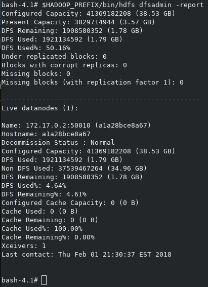

### % de Utilización del DFS

¿Cuál es el % de DFS utilizado una vez que ya subiste los datos?

*Pasó de 0.01% a 50.16%; estos porcentajes son de 354.04 KB a tener 1.79 GB con el archivo de Ecobici.*

*Aquí mostramos en color rojo la salida que responde la pregunta de esta tarea.*

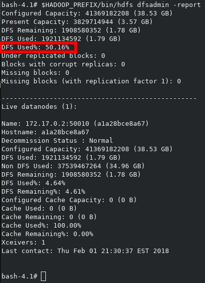

### Dockerfile

*Fuente https://store.docker.com/community/images/sequenceiq/hadoop-docker/dockerfile*

```
# Creates pseudo distributed hadoop 2.7.0
#
# docker build -t sequenceiq/hadoop .

FROM sequenceiq/pam:centos-6.5
MAINTAINER SequenceIQ

USER root

# install dev tools
RUN yum clean all; \
rpm --rebuilddb; \
yum install -y curl which tar sudo openssh-server openssh-clients rsync
# update libselinux. see https://github.com/sequenceiq/hadoop-docker/issues/14
RUN yum update -y libselinux

# passwordless ssh
RUN ssh-keygen -q -N "" -t dsa -f /etc/ssh/ssh_host_dsa_key
RUN ssh-keygen -q -N "" -t rsa -f /etc/ssh/ssh_host_rsa_key
RUN ssh-keygen -q -N "" -t rsa -f /root/.ssh/id_rsa
RUN cp /root/.ssh/id_rsa.pub /root/.ssh/authorized_keys


# java
RUN curl -LO 'http://download.oracle.com/otn-pub/java/jdk/7u71-b14/jdk-7u71-linux-x64.rpm' -H 'Cookie: oraclelicense=accept-securebackup-cookie'
RUN rpm -i jdk-7u71-linux-x64.rpm
RUN rm jdk-7u71-linux-x64.rpm

ENV JAVA_HOME /usr/java/default
ENV PATH $PATH:$JAVA_HOME/bin

# download native support
RUN mkdir -p /tmp/native
RUN curl -Ls http://dl.bintray.com/sequenceiq/sequenceiq-bin/hadoop-native-64-2.7.0.tar | tar -x -C /tmp/native

# hadoop
RUN curl -s http://www.eu.apache.org/dist/hadoop/common/hadoop-2.7.0/hadoop-2.7.0.tar.gz | tar -xz -C /usr/local/
RUN cd /usr/local && ln -s ./hadoop-2.7.0 hadoop

ENV HADOOP_PREFIX /usr/local/hadoop
```

[output cut: 54 more lines]

```
RUN echo "Port 2122" >> /etc/ssh/sshd_config

RUN service sshd start && $HADOOP_PREFIX/etc/hadoop/hadoop-env.sh && $HADOOP_PREFIX/sbin/start-dfs.sh && $HADOOP_PREFIX/bin/hdfs dfs -mkdir -p /user/root
RUN service sshd start && $HADOOP_PREFIX/etc/hadoop/hadoop-env.sh && $HADOOP_PREFIX/sbin/start-dfs.sh && $HADOOP_PREFIX/bin/hdfs dfs -put $HADOOP_PREFIX/etc/hadoop/ input

CMD ["/etc/bootstrap.sh", "-d"]

# Hdfs ports
EXPOSE 50010 50020 50070 50075 50090
# Mapred ports
EXPOSE 19888
#Yarn ports
EXPOSE 8030 8031 8032 8033 8040 8042 8088
#Other ports
EXPOSE 49707 2122
```

### Referencias

- [github.com/silil/metodos_gran_escala/hadoop.html](https://github.com/silil/metodos_gran_escala/blob/master/hadoop.html)